# 2023 Travelers Analytics

```python
import pandas as pd

# Load the data
data = pd.read_csv('D://Kaggle_competetion//2023-travelers-university-competition//InsNova_data_2023_train.csv')

# Check for null values
null_values = data.isnull().sum()

# Provide a summary of the data
data_summary = data.describe(include='all')

null_values
```

```
id                       0
veh_value                0
exposure                 0
veh_body                 0
veh_age                  0
gender                   0
area                     0
agecat                   0
engine_type              0
max_power                0
driving_history_score    0
veh_color                0
marital_status           0
e_bill                   0
time_of_week_driven      0
time_driven              0
trm_len                  0
credit_score             0
high_education_ind       0
clm                      0
numclaims                0
claimcst0                0
dtype: int64
```

```python
data
```

|  | id | veh_value | exposure | veh_body | veh_age | gender | area | agecat | engine_type | max_power | ... | marital_status | e_bill | time_of_week_driven | time_driven | trm_len | credit_score | high_education_ind | clm | numclaims | claimcst0 |
| --- | --- | --- | --- | --- | --- | --- | --- | --- | --- | --- | --- | --- | --- | --- | --- | --- | --- | --- | --- | --- | --- |
| 0 | 1 | 0.77 | 0.444504 | SEDAN | 4 | M | D | 3 | petrol | 147 | ... | S | 1 | weekday | 6pm - 12am | 6 | 640.448137 | 1.0 | 0 | 0 | 0.000000 |
| 1 | 2 | 4.45 | 0.562183 | STNWG | 1 | M | A | 3 | petrol | 158 | ... | S | 1 | weekday | 6am - 12pm | 12 | 683.749691 | 0.0 | 0 | 0 | 0.000000 |
| 2 | 3 | 4.90 | 0.465244 | STNWG | 1 | F | A | 3 | petrol | 159 | ... | M | 1 | weekday | 6pm - 12am | 6 | 653.656117 | 1.0 | 0 | 0 | 0.000000 |
| 3 | 4 | 0.48 | 0.271039 | PANVN | 4 | M | A | 4 | petrol | 80 | ... | S | 1 | weekday | 12pm - 6pm | 12 | 642.574671 | 0.0 | 0 | 0 | 0.000000 |
| 4 | 5 | 0.85 | 0.141624 | SEDAN | 4 | F | A | 5 | petrol | 126 | ... | S | 0 | weekday | 6am - 12pm | 6 | 647.175035 | 0.0 | 0 | 0 | 0.000000 |
| ... | ... | ... | ... | ... | ... | ... | ... | ... | ... | ... | ... | ... | ... | ... | ... | ... | ... | ... | ... | ... | ... |
| 22614 | 22615 | 3.71 | 0.580943 | STNWG | 2 | F | B | 2 | petrol | 154 | ... | M | 1 | weekday | 6pm - 12am | 12 | 654.451512 | 0.0 | 1 | 1 | 280.403348 |
| 22615 | 22616 | 0.77 | 0.636641 | SEDAN | 4 | F | C | 6 | petrol | 160 | ... | M | 1 | weekday | 12pm - 6pm | 12 | 641.163999 | 0.0 | 0 | 0 | 0.000000 |
| 22616 | 22617 | 1.95 | 0.709227 | HBACK | 1 | M | C | 6 | petrol | 146 | ... | M | 1 | weekday | 12am - 6 am | 12 | 649.644433 | 0.0 | 1 | 2 | 1253.261110 |
| 22617 | 22618 | 3.80 | 0.600221 | TRUCK | 2 | M | A | 4 | petrol | 284 | ... | S | 0 | weekday | 6pm - 12am | 12 | 653.024119 | 0.0 | 0 | 0 | 0.000000 |
| 22618 | 22619 | 1.62 | 0.926974 | STNWG | 4 | F | C | 4 | petrol | 104 | ... | S | 0 | weekday | 12pm - 6pm | 12 | 647.782582 | 1.0 | 0 | 0 | 0.000000 |

22619 rows × 22 columns

```python
 data_summary
```

|  | id | veh_value | exposure | veh_body | veh_age | gender | area | agecat | engine_type | max_power | ... | marital_status | e_bill | time_of_week_driven | time_driven | trm_len | credit_score | high_education_ind | clm | numclaims | claimcst0 |
| --- | --- | --- | --- | --- | --- | --- | --- | --- | --- | --- | --- | --- | --- | --- | --- | --- | --- | --- | --- | --- | --- |
| count | 22619.000000 | 22619.000000 | 22619.000000 | 22619 | 22619.000000 | 22619 | 22619 | 22619.000000 | 22619 | 22619.000000 | ... | 22619 | 22619.00000 | 22619 | 22619 | 22619.000000 | 22619.000000 | 22619.000000 | 22619.000000 | 22619.000000 | 22619.000000 |
| unique | NaN | NaN | NaN | 13 | NaN | 2 | 6 | NaN | 4 | NaN | ... | 2 | NaN | 2 | 4 | NaN | NaN | NaN | NaN | NaN | NaN |
| top | NaN | NaN | NaN | SEDAN | NaN | F | C | NaN | petrol | NaN | ... | M | NaN | weekday | 12pm - 6pm | NaN | NaN | NaN | NaN | NaN | NaN |
| freq | NaN | NaN | NaN | 7376 | NaN | 12853 | 6944 | NaN | 14146 | NaN | ... | 12401 | NaN | 18105 | 9102 | NaN | NaN | NaN | NaN | NaN | NaN |
| mean | 11310.000000 | 1.868948 | 0.433038 | NaN | 2.667492 | NaN | NaN | 3.481675 | NaN | 152.447765 | ... | NaN | 0.63681 | NaN | NaN | 10.493833 | 649.875077 | 0.117114 | 0.068173 | 0.073124 | 163.048084 |
| std | 6529.687205 | 1.278588 | 0.272899 | NaN | 1.070555 | NaN | NaN | 1.420252 | NaN | 51.834156 | ... | NaN | 0.48093 | NaN | NaN | 2.601685 | 10.515364 | 0.321563 | 0.252048 | 0.280142 | 1271.955238 |
| min | 1.000000 | 0.000000 | 0.001754 | NaN | 1.000000 | NaN | NaN | 1.000000 | NaN | 60.000000 | ... | NaN | 0.00000 | NaN | NaN | 6.000000 | 607.797435 | 0.000000 | 0.000000 | 0.000000 | 0.000000 |
| 25% | 5655.500000 | 1.070000 | 0.203696 | NaN | 2.000000 | NaN | NaN | 2.000000 | NaN | 115.000000 | ... | NaN | 0.00000 | NaN | NaN | 6.000000 | 643.134748 | 0.000000 | 0.000000 | 0.000000 | 0.000000 |
| 50% | 11310.000000 | 1.570000 | 0.384313 | NaN | 3.000000 | NaN | NaN | 3.000000 | NaN | 144.000000 | ... | NaN | 1.00000 | NaN | NaN | 12.000000 | 647.180197 | 0.000000 | 0.000000 | 0.000000 | 0.000000 |
| 75% | 16964.500000 | 2.260000 | 0.643316 | NaN | 4.000000 | NaN | NaN | 5.000000 | NaN | 180.000000 | ... | NaN | 1.00000 | NaN | NaN | 12.000000 | 654.069205 | 0.000000 | 0.000000 | 0.000000 | 0.000000 |
| max | 22619.000000 | 24.510000 | 0.999378 | NaN | 4.000000 | NaN | NaN | 6.000000 | NaN | 409.000000 | ... | NaN | 1.00000 | NaN | NaN | 12.000000 | 790.360253 | 1.000000 | 1.000000 | 3.000000 | 57895.584560 |

11 rows × 22 columns

```python
data[data['clm']==0]
```

|  | id | veh_value | exposure | veh_body | veh_age | gender | area | agecat | engine_type | max_power | ... | marital_status | e_bill | time_of_week_driven | time_driven | trm_len | credit_score | high_education_ind | clm | numclaims | claimcst0 |
| --- | --- | --- | --- | --- | --- | --- | --- | --- | --- | --- | --- | --- | --- | --- | --- | --- | --- | --- | --- | --- | --- |
| 0 | 1 | 0.77 | 0.444504 | SEDAN | 4 | M | D | 3 | petrol | 147 | ... | S | 1 | weekday | 6pm - 12am | 6 | 640.448137 | 1.0 | 0 | 0 | 0.0 |
| 1 | 2 | 4.45 | 0.562183 | STNWG | 1 | M | A | 3 | petrol | 158 | ... | S | 1 | weekday | 6am - 12pm | 12 | 683.749691 | 0.0 | 0 | 0 | 0.0 |
| 2 | 3 | 4.90 | 0.465244 | STNWG | 1 | F | A | 3 | petrol | 159 | ... | M | 1 | weekday | 6pm - 12am | 6 | 653.656117 | 1.0 | 0 | 0 | 0.0 |
| 3 | 4 | 0.48 | 0.271039 | PANVN | 4 | M | A | 4 | petrol | 80 | ... | S | 1 | weekday | 12pm - 6pm | 12 | 642.574671 | 0.0 | 0 | 0 | 0.0 |
| 4 | 5 | 0.85 | 0.141624 | SEDAN | 4 | F | A | 5 | petrol | 126 | ... | S | 0 | weekday | 6am - 12pm | 6 | 647.175035 | 0.0 | 0 | 0 | 0.0 |
| ... | ... | ... | ... | ... | ... | ... | ... | ... | ... | ... | ... | ... | ... | ... | ... | ... | ... | ... | ... | ... | ... |
| 22612 | 22613 | 2.58 | 0.584393 | MIBUS | 3 | F | A | 3 | dissel | 161 | ... | M | 1 | weekend | 12pm - 6pm | 12 | 663.832643 | 0.0 | 0 | 0 | 0.0 |
| 22613 | 22614 | 1.54 | 0.286243 | UTE | 3 | M | C | 2 | petrol | 247 | ... | S | 0 | weekend | 12pm - 6pm | 6 | 642.832123 | 0.0 | 0 | 0 | 0.0 |
| 22615 | 22616 | 0.77 | 0.636641 | SEDAN | 4 | F | C | 6 | petrol | 160 | ... | M | 1 | weekday | 12pm - 6pm | 12 | 641.163999 | 0.0 | 0 | 0 | 0.0 |
| 22617 | 22618 | 3.80 | 0.600221 | TRUCK | 2 | M | A | 4 | petrol | 284 | ... | S | 0 | weekday | 6pm - 12am | 12 | 653.024119 | 0.0 | 0 | 0 | 0.0 |
| 22618 | 22619 | 1.62 | 0.926974 | STNWG | 4 | F | C | 4 | petrol | 104 | ... | S | 0 | weekday | 12pm - 6pm | 12 | 647.782582 | 1.0 | 0 | 0 | 0.0 |

21077 rows × 22 columns

```python
new_main=data[data['clm']==1]
```

```python
new_main.columns
```

```
Index(['id', 'veh_value', 'exposure', 'veh_body', 'veh_age', 'gender', 'area',
       'agecat', 'engine_type', 'max_power', 'driving_history_score',
       'veh_color', 'marital_status', 'e_bill', 'time_of_week_driven',
       'time_driven', 'trm_len', 'credit_score', 'high_education_ind', 'clm',
       'numclaims', 'claimcst0'],
      dtype='object')
```

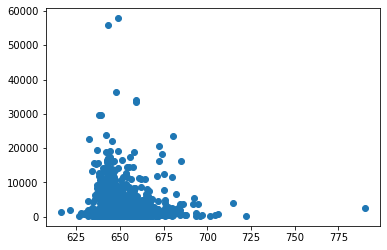

```python
import matplotlib.pyplot as plt
plt.scatter(new_main["credit_score"],new_main['claimcst0'])
```

```python
filtered_data = data[(data['clm'] == 1) & (data['claimcst0'] == 0)]
```

```python
filtered_data
```

|  | id | veh_value | exposure | veh_body | veh_age | gender | area | agecat | engine_type | max_power | ... | marital_status | e_bill | time_of_week_driven | time_driven | trm_len | credit_score | high_education_ind | clm | numclaims | claimcst0 |
| --- | --- | --- | --- | --- | --- | --- | --- | --- | --- | --- | --- | --- | --- | --- | --- | --- | --- | --- | --- | --- | --- |

0 rows × 22 columns

```python
data.columns
```

```
Index(['id', 'veh_value', 'exposure', 'veh_body', 'veh_age', 'gender', 'area',
       'agecat', 'engine_type', 'max_power', 'driving_history_score',
       'veh_color', 'marital_status', 'e_bill', 'time_of_week_driven',
       'time_driven', 'trm_len', 'credit_score', 'high_education_ind', 'clm',
       'numclaims', 'claimcst0'],
      dtype='object')
```

```python
print("Shape of the data is ", data.shape)
```

```
Shape of the data is  (22619, 22)
```

There are 22,619 records in the dataset. For the Veh_body, the most frequent type is 'SEDAN'. For Gender, there are two unique values (presumably Male and Female) with 'F' being more frequent. For the Area, the most common area is 'C'. The average Veh_value is approximately 1.87 (or $18,700 when scaled up). The average Max_power is about 152.45 horsepower. The average Credit_score is approximately 649.88. About 6.8% of the policies had a claim, as indicated by the average of Claim_ind (0.068173). The average claim cost (Claim_cost) is $163.05, but the standard deviation is large, indicating variability in the claim amounts

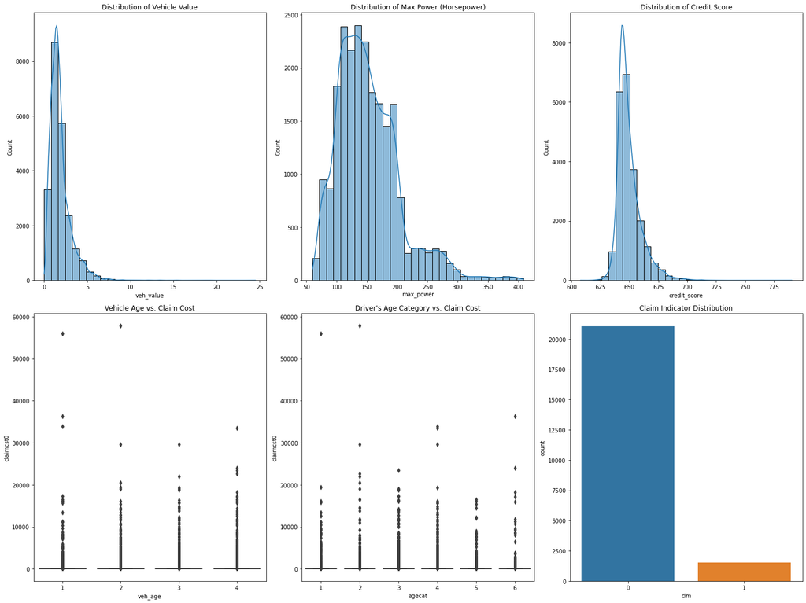

```python
import matplotlib.pyplot as plt
import seaborn as sns

# Set up the matplotlib figure
plt.figure(figsize=(20, 15))

# Distribution of Vehicle Value
plt.subplot(2, 3, 1)
sns.histplot(data['veh_value'], kde=True, bins=30)
plt.title('Distribution of Vehicle Value')

# Distribution of Max Power
plt.subplot(2, 3, 2)
sns.histplot(data['max_power'], kde=True, bins=30)
plt.title('Distribution of Max Power (Horsepower)')

# Distribution of Credit Score
plt.subplot(2, 3, 3)
sns.histplot(data['credit_score'], kde=True, bins=30)
plt.title('Distribution of Credit Score')

# Vehicle Age vs. Claim Cost
plt.subplot(2, 3, 4)
sns.boxplot(x=data['veh_age'], y=data['claimcst0'])
plt.title('Vehicle Age vs. Claim Cost')

# Driver's Age Category vs. Claim Cost
plt.subplot(2, 3, 5)
sns.boxplot(x=data['agecat'], y=data['claimcst0'])
plt.title("Driver's Age Category vs. Claim Cost")

# Claim Indicator Distribution
plt.subplot(2, 3, 6)
sns.countplot(data['clm'])
plt.title('Claim Indicator Distribution')

plt.tight_layout()
plt.show()
```

# Count Plots for the Categorical ones

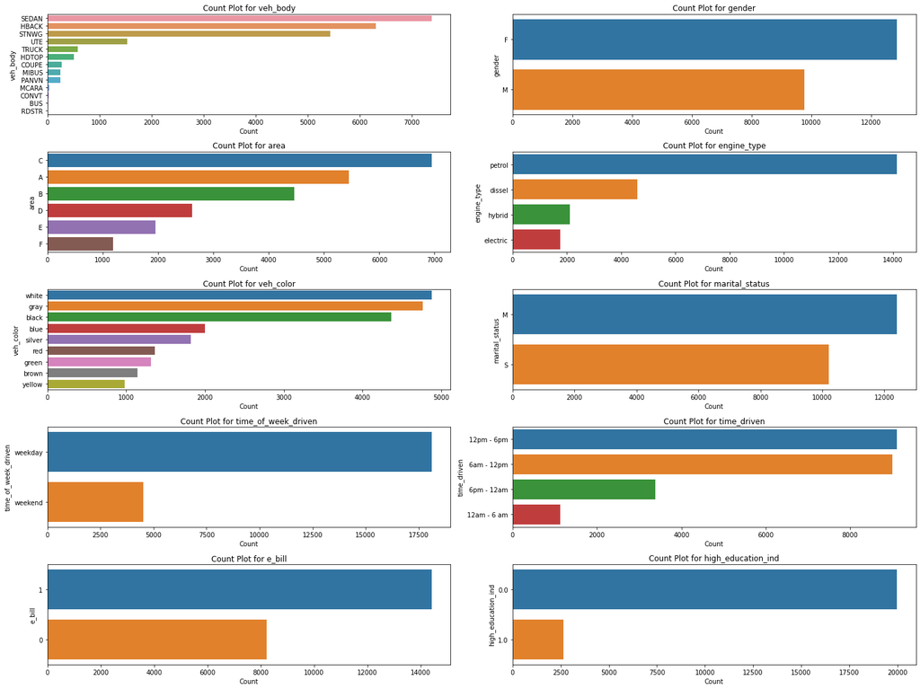

```python
# List of categorical variables
categorical_vars = ['veh_body', 'gender', 'area', 'engine_type', 'veh_color', 'marital_status',
                    'time_of_week_driven', 'time_driven', 'e_bill', 'high_education_ind']

# Setting up the matplotlib figure
plt.figure(figsize=(20, 15))

# Plotting count plots for each categorical variable
for i, var in enumerate(categorical_vars, 1):
    plt.subplot(5, 2, i)
    sns.countplot(data=data, y=var, order=data[var].value_counts().index)
    plt.title(f'Count Plot for {var}')
    plt.ylabel(var)
    plt.xlabel('Count')

plt.tight_layout()
plt.show()
```

## 1. How does the claim frequency vary across different vehicle bodies and engine types? Understanding this could help in segmenting policies based on risk.

## 2. Is there a relationship between driving history score and claim cost? This would validate the importance of driving history in predicting future claims.

## 3. How does the claim frequency and average claim cost vary by area of residence and driver's age category? This could indicate if certain areas or age groups are riskier than others.

## 4.Does having a higher education correlate with fewer claims or lower claim costs? This would help in understanding the impact of education on driving behavior.

## 5.Do drivers who opt for paperless billing (E-bill) have a different claim pattern compared to those who don't? This could provide insights into the behavior of digitally savvy customers.

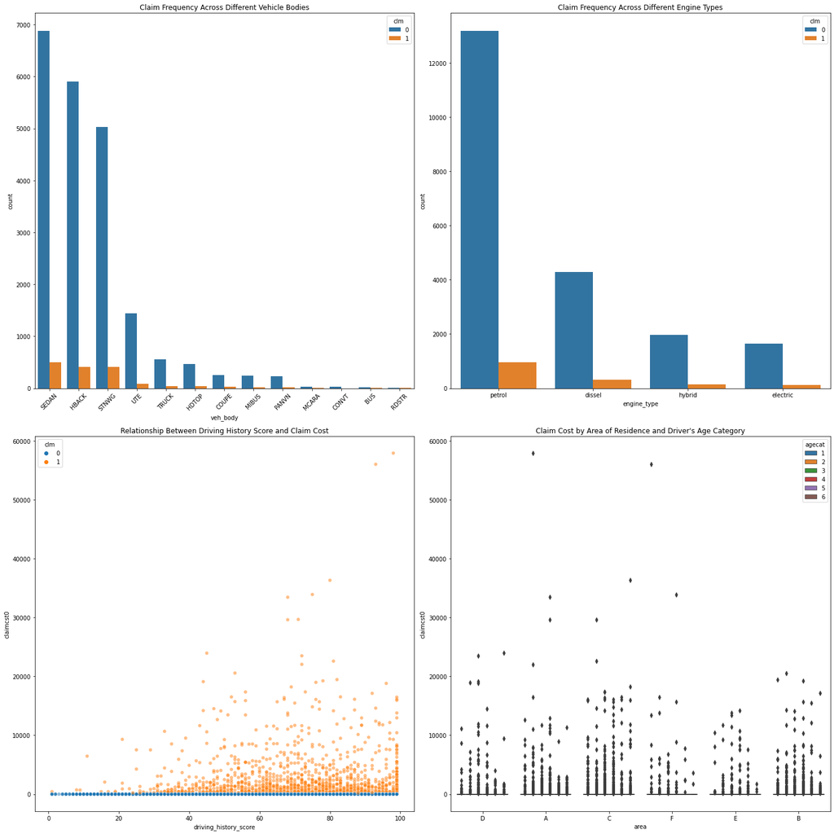

```python
# Set up the matplotlib figure
plt.figure(figsize=(20, 20))

# 1. How does the claim frequency vary across different vehicle bodies and engine types?
plt.subplot(2, 2, 1)
sns.countplot(data=data, x='veh_body', hue='clm', order=data['veh_body'].value_counts().index)
plt.title('Claim Frequency Across Different Vehicle Bodies')
plt.xticks(rotation=45)

plt.subplot(2, 2, 2)
sns.countplot(data=data, x='engine_type', hue='clm', order=data['engine_type'].value_counts().index)
plt.title('Claim Frequency Across Different Engine Types')

# 2. Is there a relationship between driving history score and claim cost?
plt.subplot(2, 2, 3)
sns.scatterplot(data=data, x='driving_history_score', y='claimcst0', hue='clm', alpha=0.5)
plt.title('Relationship Between Driving History Score and Claim Cost')

# 3. How does the claim frequency and average claim cost vary by area of residence and driver's age category?
plt.subplot(2, 2, 4)
sns.boxplot(data=data, x='area', y='claimcst0', hue='agecat')
plt.title('Claim Cost by Area of Residence and Driver\'s Age Category')

plt.tight_layout()
plt.show()
```

Claim Frequency Across Different Vehicle Bodies:

Sedans, Hatchbacks, and Station Wagons have the highest claim frequencies. However, it's also important to note that these vehicle types are more common in the dataset, so the absolute numbers are higher. Claim Frequency Across Different Engine Types:

```python
data['high_education_ind']
```

```
0        1.0
1        0.0
2        1.0
3        0.0
4        0.0
        ...
22614    0.0
22615    0.0
22616    0.0
22617    0.0
22618    1.0
Name: high_education_ind, Length: 22619, dtype: float64
```

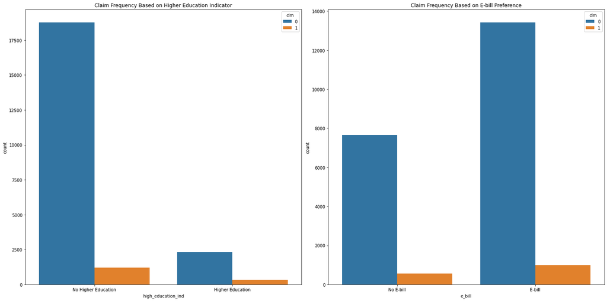

```python
# Set up the matplotlib figure
plt.figure(figsize=(20, 10))

# 4. Does having a higher education correlate with fewer claims or lower claim costs?
plt.subplot(1, 2, 1)
sns.countplot(data=data, x='high_education_ind', hue='clm')
plt.title('Claim Frequency Based on Higher Education Indicator')
plt.xticks(ticks=[0,1], labels=['No Higher Education', 'Higher Education'])

# 5. Do drivers who opt for paperless billing (E-bill) have a different claim pattern compared to those who don't?
plt.subplot(1, 2, 2)
sns.countplot(data=data, x='e_bill', hue='clm')
plt.title('Claim Frequency Based on E-bill Preference')
plt.xticks(ticks=[0,1], labels=['No E-bill', 'E-bill'])

plt.tight_layout()
plt.show()
```

Claim Frequency Based on Higher Education Indicator:

Individuals who opt for E-bill (paperless billing) seem to have a slightly higher claim frequency relative to their representation in the dataset. This is a bit counterintuitive and might indicate that the E-bill variable correlates with some other behavior or characteristic of the driver.

# Is there an interaction effect between driver's age, vehicle age, and area of residence on the claim costs?

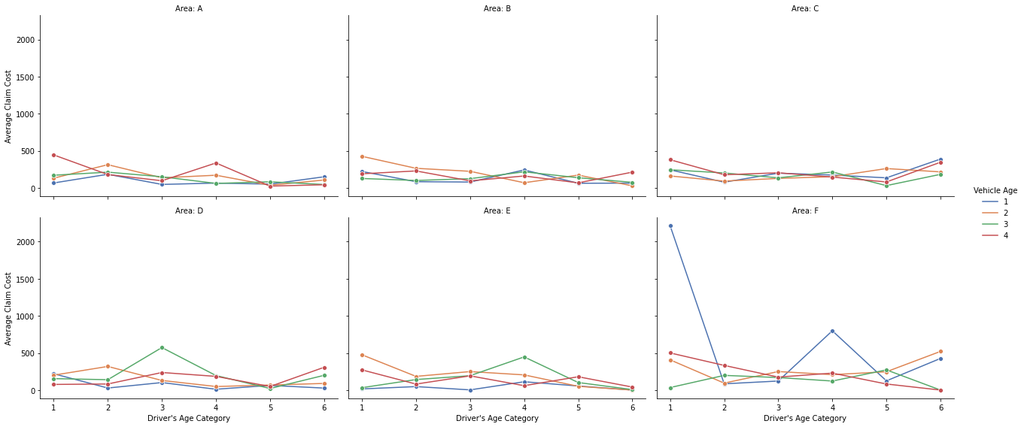

```python
# Grouping data by area, driver's age, and vehicle age to calculate average claim costs
grouped_data = data.groupby(['area', 'agecat', 'veh_age'])['claimcst0'].mean().reset_index()

# Create a FacetGrid to visualize the interaction effect
g = sns.FacetGrid(grouped_data, col="area", col_wrap=3, height=4, aspect=1.5)
g = (g.map(sns.lineplot, "agecat", "claimcst0", "veh_age", palette="deep", marker="o")
     .add_legend(title="Vehicle Age")
     .set_axis_labels("Driver's Age Category", "Average Claim Cost")
     .set_titles("Area: {col_name}"))

# Adjusting the layout
g.tight_layout()
plt.show()
```

In most areas, the average claim cost tends to decrease or remain fairly constant as the driver's age category increases. This suggests that older drivers, on average, may have lower claim costs.

The effect of vehicle age on claim costs varies across areas and driver age categories. In some areas, newer vehicles (age 1) tend to have higher claim costs, while in other areas, the trend is the opposite.

For Area 'A', older vehicles driven by younger individuals seem to have the highest average claim costs.

Areas 'C', 'D', 'E', and 'F' show more complex patterns where the relationship between driver's age, vehicle age, and claim costs isn't as straightforward.

## 1.How does driving behavior, as indicated by the time of week and time of day driven, impact the claim frequency and cost? Understanding patterns of risk based on driving behavior can be crucial for targeted policy pricing.

## 2.Is there an interaction effect between vehicle body type, engine type, and credit score on the claim frequency? This can help in understanding if certain combinations of vehicle attributes and driver financial responsibility are more likely to result in claims.

## 3.Do drivers with a higher driving history score, segmented by gender and marital status, have a different claim frequency and cost? This will explore if demographic factors combined with driving history provide additional insights into claim patterns.

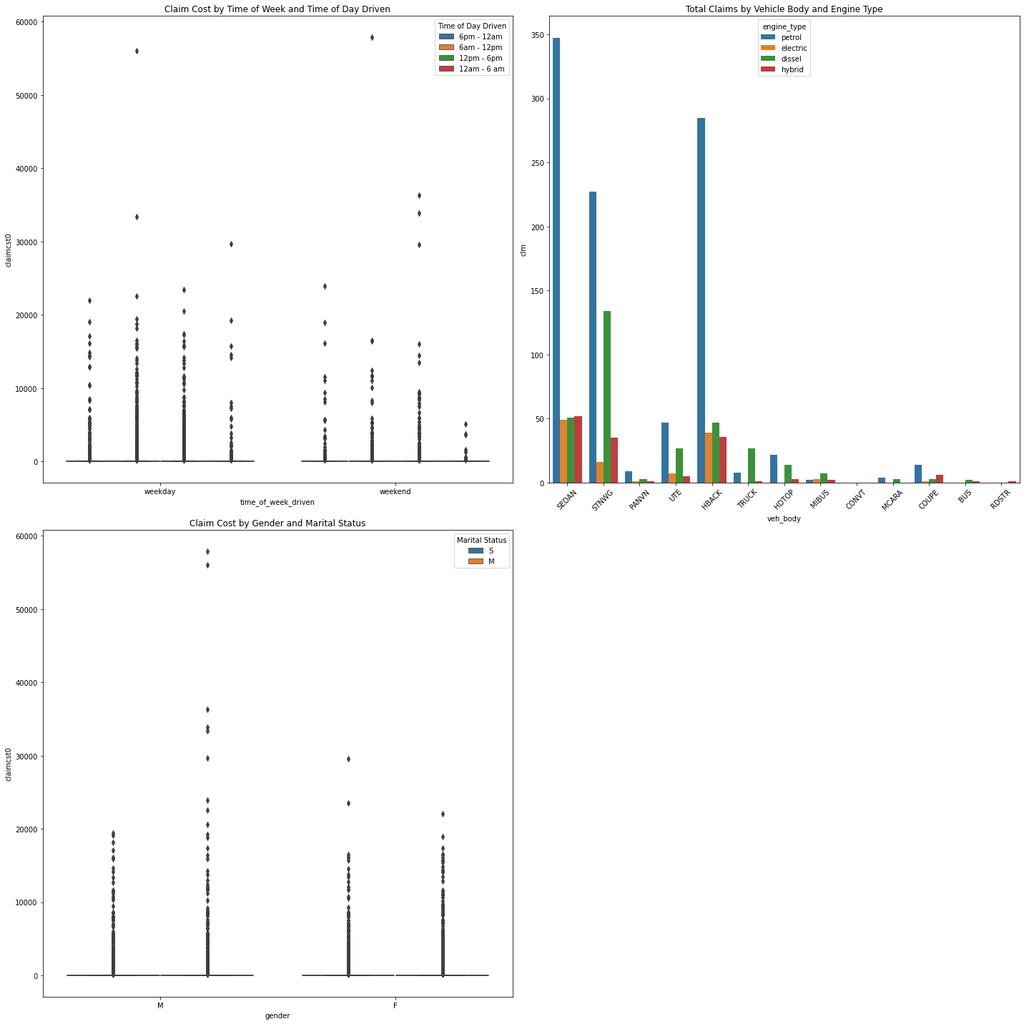

```python
# Set up the matplotlib figure
plt.figure(figsize=(20, 20))

# 1. How does driving behavior impact the claim frequency and cost?
plt.subplot(2, 2, 1)
sns.boxplot(data=data, x='time_of_week_driven', y='claimcst0', hue='time_driven')
plt.title('Claim Cost by Time of Week and Time of Day Driven')
plt.legend(title='Time of Day Driven', loc='upper right')

# 2. Interaction effect between vehicle body type, engine type, and credit score on the claim frequency
# For visualization, we'll bin the credit scores into three categories: Low, Medium, High
data['credit_score_bin'] = pd.cut(data['credit_score'], bins=[600, 640, 680, 800], labels=['Low', 'Medium', 'High'])
plt.subplot(2, 2, 2)
sns.barplot(data=data, x='veh_body', y='clm', hue='engine_type', ci=None, estimator=sum)
plt.title('Total Claims by Vehicle Body and Engine Type')
plt.xticks(rotation=45)

# 3. Claim frequency and cost by driving history score, segmented by gender and marital status
plt.subplot(2, 2, 3)
sns.boxplot(data=data, x='gender', y='claimcst0', hue='marital_status')
plt.title('Claim Cost by Gender and Marital Status')
plt.legend(title='Marital Status', loc='upper right')

plt.tight_layout()
plt.show()
```

# Base Model

```python
from sklearn.model_selection import train_test_split
from sklearn.preprocessing import LabelEncoder

# Encoding categorical variables
label_encoders = {}
for col in categorical_vars:
    le = LabelEncoder()
    data[col] = le.fit_transform(data[col])
    label_encoders[col] = le
```

```python
# Splitting data into training and validation sets (using the correct column names)
X = data.drop(columns=['clm', 'numclaims', 'claimcst0','id'])
y = data['claimcst0']

X_train, X_val, y_train, y_val = train_test_split(X, y, test_size=0.2, random_state=42)

X_train.shape, X_val.shape
```

```
((18095, 18), (4524, 18))
```

```python
X_train.columns
```

```
Index(['veh_value', 'exposure', 'veh_body', 'veh_age', 'gender', 'area',
       'agecat', 'engine_type', 'max_power', 'driving_history_score',
       'veh_color', 'marital_status', 'e_bill', 'time_of_week_driven',
       'time_driven', 'trm_len', 'credit_score', 'high_education_ind'],
      dtype='object')
```

```python
import lightgbm as lgb
from sklearn.metrics import roc_auc_score

# Training the benchmark LightGBM model
lgb_train = lgb.Dataset(X_train, y_train)
lgb_val = lgb.Dataset(X_val, y_val, reference=lgb_train)

params = {
    'boosting_type': 'gbdt',
    'objective': 'regression',
    'metric': 'rmse',
    'num_leaves': 31,
    'learning_rate': 0.05,
    'feature_fraction': 0.9
}

# Train the model
num_round = 100
```

```python
# Train the LightGBM model with the corrected parameters for early stopping
lgb_benchmark = lgb.train(params,
                          lgb_train,
                          num_boost_round=num_round,
                          valid_sets=[lgb_val])
```

```
[LightGBM] [Info] Auto-choosing row-wise multi-threading, the overhead of testing was 0.001959 seconds.
You can set `force_row_wise=true` to remove the overhead.
And if memory is not enough, you can set `force_col_wise=true`.
[LightGBM] [Info] Total Bins 1180
[LightGBM] [Info] Number of data points in the train set: 18095, number of used features: 18
[LightGBM] [Info] Start training from score 159.060205
```

```python
# Predict on validation set
y_pred_val = lgb_benchmark.predict(X_val, num_iteration=lgb_benchmark.best_iteration)

# Since Gini index is equivalent to 2*AUC - 1, we will calculate the AUC first
# Convert the target variable to binary (0 if no claim, 1 if there's a claim)
y_val_binary = (y_val > 0).astype(int)
auc = roc_auc_score(y_val_binary, y_pred_val)
gini_benchmark = 2 * auc - 1
```

```python
gini_benchmark
```

```
0.2060626010877169
```

```python
gini_benchmark
```

```
0.2060626010877169
```

```python
# Load the test data
test_data = pd.read_csv('D://Kaggle_competetion//2023-travelers-university-competition//InsNova_data_2023_vh.csv')

# Encoding categorical variables in the test data
for col in categorical_vars:
    le = label_encoders[col]
    test_data[col] = le.transform(test_data[col])

# Predict on test data
test_data_X = test_data.drop(columns=['id'])
y_pred_test = lgb_benchmark.predict(test_data_X, num_iteration=lgb_benchmark.best_iteration)

# Create a submission file
submission = pd.DataFrame({
    'id': test_data['id'],
    'Predict': y_pred_test
})

# Save the submission file
submission.to_csv('D://Kaggle_competetion//2023-travelers-university-competition//submission_1.csv', index=False)
```

```python
submission
```

|  | id | Predict |
| --- | --- | --- |
| 0 | 1 | 335.549037 |
| 1 | 2 | 273.099302 |
| 2 | 3 | 10.392352 |
| 3 | 4 | 139.055005 |
| 4 | 5 | 83.632716 |
| ... | ... | ... |
| 22615 | 22616 | 294.765464 |
| 22616 | 22617 | 30.301187 |
| 22617 | 22618 | 161.799511 |
| 22618 | 22619 | 157.289646 |
| 22619 | 22620 | 379.852727 |

22620 rows × 2 columns

# Catboost

```python
from catboost import CatBoostRegressor
```

```python
# Training the CatBoost model
model = CatBoostRegressor(
    iterations=100,
    depth=6,
    learning_rate=0.1,
    loss_function='RMSE',
    cat_features=categorical_vars
)
model.fit(X_train, y_train, eval_set=(X_val, y_val), use_best_model=True)

# Predict on validation set
y_pred_val = model.predict(X_val)

# Since Gini index is equivalent to 2*AUC - 1, we will calculate the AUC first
# Convert the target variable to binary (0 if no claim, 1 if there's a claim)
y_val_binary = (y_val > 0).astype(int)
auc = roc_auc_score(y_val_binary, y_pred_val)
gini_index = 2 * auc - 1
```

[output not shown]

[output cut: 50 more lines]

```
90:	learn: 1166.3585270	test: 1406.1507108	best: 1399.3271906 (1)	total: 2.22s	remaining: 219ms
91:	learn: 1166.3509789	test: 1406.1365963	best: 1399.3271906 (1)	total: 2.24s	remaining: 195ms
92:	learn: 1166.0908160	test: 1406.1450285	best: 1399.3271906 (1)	total: 2.26s	remaining: 170ms
93:	learn: 1166.0288983	test: 1406.1728440	best: 1399.3271906 (1)	total: 2.29s	remaining: 146ms
94:	learn: 1165.9304530	test: 1406.1749392	best: 1399.3271906 (1)	total: 2.31s	remaining: 122ms
95:	learn: 1165.8763428	test: 1406.1877651	best: 1399.3271906 (1)	total: 2.32s	remaining: 96.8ms
96:	learn: 1165.8533572	test: 1406.1940668	best: 1399.3271906 (1)	total: 2.34s	remaining: 72.5ms
97:	learn: 1165.8518138	test: 1406.1973515	best: 1399.3271906 (1)	total: 2.36s	remaining: 48.1ms
98:	learn: 1164.5573048	test: 1406.2089846	best: 1399.3271906 (1)	total: 2.38s	remaining: 24.1ms
99:	learn: 1164.4764650	test: 1406.2770363	best: 1399.3271906 (1)	total: 2.4s	remaining: 0us

bestTest = 1399.327191
bestIteration = 1

Shrink model to first 2 iterations.
```

[output not shown]

```python
print(f"Gini index: {gini_index}")
```

[output not shown]

```python
# Load the test data
test_data = pd.read_csv('InsNova_data_2023_vh.csv')

# Encoding categorical variables in the test data
for col in categorical_vars:
    le = label_encoders[col]
    classes = le.classes_.tolist()
    if test_data[col].dtype == 'object':
        test_data[col] = test_data[col].astype(str)
    test_data[col] = test_data[col].apply(lambda x: x if x in classes else 'Unknown')
    le.classes_ = np.append(le.classes_, 'Unknown')
    test_data[col] = le.transform(test_data[col])
```

```python
# Predict on test data
test_data_X = test_data.drop(columns=['id'])
y_pred_test = model.predict(test_data_X)
```

```python
# Create a submission file
submission = pd.DataFrame({
    'id': test_data['id'],
    'Predict': y_pred_test
})

# Save the submission file
submission.to_csv('D://Kaggle_competetion//2023-travelers-university-competition//submission_1_catboost.csv', index=False)
```

# Ensmble_Model

```python
import pandas as pd
import numpy as np
from sklearn.model_selection import train_test_split
from sklearn.metrics import roc_auc_score
from catboost import CatBoostRegressor
from xgboost import XGBRegressor
from lightgbm import LGBMRegressor
from sklearn.ensemble import VotingRegressor
from sklearn.preprocessing import LabelEncoder
```

```python
# Train CatBoost model
cb_model = CatBoostRegressor(iterations=100, depth=6, learning_rate=0.1, loss_function='RMSE', cat_features=categorical_vars)
cb_model.fit(X_train, y_train, eval_set=(X_val, y_val), use_best_model=True)

# Train XGBoost model
xgb_model = XGBRegressor(n_estimators=100, max_depth=6, learning_rate=0.1)
xgb_model.fit(X_train, y_train)

# Train LightGBM model
lgb_model = LGBMRegressor(n_estimators=100, max_depth=6, learning_rate=0.1)
lgb_model.fit(X_train, y_train)

# Ensemble models
ensemble_model = VotingRegressor(estimators=[('cb', cb_model), ('xgb', xgb_model), ('lgb', lgb_model)], weights=[0.4, 0.3, 0.3])
ensemble_model.fit(X_train, y_train)

# Predict on validation set
y_pred_val = ensemble_model.predict(X_val)

# Calculate Gini index
y_val_binary = (y_val > 0).astype(int)
auc = roc_auc_score(y_val_binary, y_pred_val)
gini_index = 2 * auc - 1

print(f"Gini index: {gini_index}")
```

[output not shown]

[output cut: 224 more lines]

[output not shown]

```python
print(f"Gini index: {gini_index}")
```

```
Gini index: 0.2215752774967965
```

```python
# Load the test data
test_data = pd.read_csv('InsNova_data_2023_vh.csv')

# Encoding categorical variables in the test data
for col in categorical_vars:
    le = label_encoders[col]
    classes = le.classes_.tolist()
    if test_data[col].dtype == 'object':
        test_data[col] = test_data[col].astype(str)
    test_data[col] = test_data[col].apply(lambda x: x if x in classes else 'Unknown')
    le.classes_ = np.append(le.classes_, 'Unknown')
    test_data[col] = le.transform(test_data[col])

# Predict on test data
test_data_X = test_data.drop(columns=['id'])
y_pred_test = ensemble_model.predict(test_data_X)
```

```
[LightGBM] [Warning] Accuracy may be bad since you didn't explicitly set num_leaves OR 2^max_depth > num_leaves. (num_leaves=31).
```

```python
# Create a submission file
submission = pd.DataFrame({
    'id': test_data['id'],
    'Predict': y_pred_test
})

# Save the submission file
submission.to_csv('D://Kaggle_competetion//2023-travelers-university-competition//submission_ensmble.csv', index=False)
```

# Catboost with standard normal

```python
import pandas as pd
from sklearn.model_selection import train_test_split
from sklearn.preprocessing import LabelEncoder, StandardScaler
from catboost import CatBoostRegressor
from sklearn.metrics import roc_auc_score

# List of categorical and continuous variables
categorical_vars = ['veh_body', 'gender', 'area', 'engine_type', 'veh_color', 'marital_status',
                    'time_of_week_driven', 'time_driven', 'e_bill', 'high_education_ind',]
continuous_vars = ['veh_value', 'max_power', 'credit_score']

# Encoding categorical variables
label_encoders = {}
for col in categorical_vars:
    le = LabelEncoder()
    data[col] = le.fit_transform(data[col])
    label_encoders[col] = le

# Drop 'credit_score_bin' from continuous_vars if it exists
if 'credit_score_bin' in continuous_vars:
    continuous_vars.remove('credit_score_bin')

# Splitting data into training and validation sets
X = data.drop(columns=['clm', 'numclaims', 'claimcst0', 'id'])
y = data['claimcst0']
X_train, X_val, y_train, y_val = train_test_split(X, y, test_size=0.2, random_state=42)

# Standardize the continuous variables
scaler = StandardScaler()
X_train[continuous_vars] = scaler.fit_transform(X_train[continuous_vars])
X_val[continuous_vars] = scaler.transform(X_val[continuous_vars])

# Initialize the CatBoost regressor
catboost_model = CatBoostRegressor(
    iterations=20000,
    depth=10,
    learning_rate=0.001,
    loss_function='RMSE',
    cat_features=categorical_vars,
    verbose=100,
    task_type="GPU",
    devices='0:1'
)

# Train the model
catboost_model.fit(X_train, y_train, eval_set=(X_val, y_val), early_stopping_rounds=100, use_best_model=True)
```

```
0:	learn: 1237.9201297	test: 1399.6666826	best: 1399.6666826 (0)	total: 198ms	remaining: 1h 6m 6s
100:	learn: 1236.3262010	test: 1399.4402620	best: 1399.4402620 (100)	total: 15.2s	remaining: 49m 51s
200:	learn: 1234.6486309	test: 1399.2617682	best: 1399.2617682 (200)	total: 30.7s	remaining: 50m 26s
300:	learn: 1233.1021493	test: 1399.1056585	best: 1399.1056585 (300)	total: 46.7s	remaining: 50m 58s
400:	learn: 1231.6498040	test: 1398.9761470	best: 1398.9761470 (400)	total: 1m 1s	remaining: 50m 25s
500:	learn: 1229.9169005	test: 1398.8551995	best: 1398.8551995 (498)	total: 1m 17s	remaining: 50m 20s
600:	learn: 1228.2125611	test: 1398.7060839	best: 1398.7060839 (600)	total: 1m 32s	remaining: 50m
700:	learn: 1226.4452708	test: 1398.6034818	best: 1398.6034818 (700)	total: 1m 49s	remaining: 50m 9s
800:	learn: 1224.7491303	test: 1398.5263635	best: 1398.5258780 (796)	total: 2m 5s	remaining: 49m 59s
900:	learn: 1223.0194976	test: 1398.4573337	best: 1398.4573337 (900)	total: 2m 20s	remaining: 49m 46s
1000:	learn: 1221.3120198	test: 1398.3868438	best: 1398.3866010 (986)	total: 2m 36s	remaining: 49m 39s
1100:	learn: 1219.5198805	test: 1398.3526091	best: 1398.3518807 (1099)	total: 2m 53s	remaining: 49m 35s
1200:	learn: 1217.7467595	test: 1398.2899649	best: 1398.2899649 (1200)	total: 3m 9s	remaining: 49m 24s
1300:	learn: 1216.1717131	test: 1398.2602605	best: 1398.2602605 (1300)	total: 3m 25s	remaining: 49m 8s
1400:	learn: 1214.5778045	test: 1398.2281272	best: 1398.2265893 (1398)	total: 3m 40s	remaining: 48m 52s
1500:	learn: 1213.0521532	test: 1398.1431364	best: 1398.1416794 (1497)	total: 3m 56s	remaining: 48m 40s
1600:	learn: 1211.4137798	test: 1398.1071149	best: 1398.1069530 (1599)	total: 4m 12s	remaining: 48m 21s
1700:	learn: 1209.7499857	test: 1398.0549024	best: 1398.0520691 (1675)	total: 4m 28s	remaining: 48m 8s
1800:	learn: 1208.1841399	test: 1398.0119167	best: 1398.0084357 (1797)	total: 4m 44s	remaining: 47m 54s
1900:	learn: 1206.8008461	test: 1397.9771871	best: 1397.9771871 (1900)	total: 4m 59s	remaining: 47m 35s
2000:	learn: 1205.2544576	test: 1397.9418091	best: 1397.9418091 (2000)	total: 5m 15s	remaining: 47m 17s
2100:	learn: 1203.6572347	test: 1397.9477999	best: 1397.9418091 (2000)	total: 5m 30s	remaining: 46m 58s
bestTest = 1397.941809
bestIteration = 2000
Shrink model to first 2001 iterations.
```

```
<catboost.core.CatBoostRegressor at 0x1de3e2646d0>
```

```python
# Predict on validation set
y_pred_val = catboost_model.predict(X_val)

# Calculate the Gini index
y_val_binary = (y_val > 0).astype(int)
auc = roc_auc_score(y_val_binary, y_pred_val)
gini_index_catboost = 2 * auc - 1

print(f"Gini index: {gini_index_catboost}")
```

```
Gini index: 0.2584133849322783
```

```python
from sklearn.model_selection import GridSearchCV

# Feature engineering
data['veh_age_value'] = data['veh_age'] * data['veh_value']
data['power_value'] = data['max_power'] * data['veh_value']

# Update the list of continuous variables
continuous_vars.extend(['veh_age_value', 'power_value'])

# Splitting data into training and validation sets
X = data.drop(columns=['clm', 'numclaims', 'claimcst0', 'id'])
y = data['claimcst0']
X_train, X_val, y_train, y_val = train_test_split(X, y, test_size=0.2, random_state=42)

# Standardize the continuous variables
scaler = StandardScaler()
X_train[continuous_vars] = scaler.fit_transform(X_train[continuous_vars])
X_val[continuous_vars] = scaler.transform(X_val[continuous_vars])

# Initialize the CatBoost regressor with updated parameters
catboost_model = CatBoostRegressor(
    iterations=20000,
    depth=10,
    learning_rate=0.001,
    loss_function='RMSE',
    cat_features=categorical_vars,
    verbose=100,
    task_type="GPU",
    devices='0:1'
)

# Set up the hyperparameter grid
param_grid = {
    'depth': [8, 10, 12],
    'learning_rate': [0.001, 0.01, 0.1],
    'iterations': [10000, 20000, 30000]
}

# Perform grid search with cross-validation
grid_search = GridSearchCV(catboost_model, param_grid, cv=3, scoring='neg_mean_squared_error', n_jobs=-1, verbose=2)
grid_search.fit(X_train, y_train)

# Train the best model on the full training data
best_model = grid_search.best_estimator_
best_model.fit(X_train, y_train, eval_set=(X_val, y_val), early_stopping_rounds=100, use_best_model=True)

# Predict on validation set
y_pred_val = best_model.predict(X_val)

# Calculate the Gini index
y_val_binary = (y_val > 0).astype(int)
auc = roc_auc_score(y_val_binary, y_pred_val)
gini_index_catboost = 2 * auc - 1

print(f"Gini index: {gini_index_catboost}")
```

[output not shown]

```
Fitting 3 folds for each of 27 candidates, totalling 81 fits
```

# #

```python
from lightgbm import LGBMRegressor
from sklearn.metrics import mean_squared_error

# Initialize the LightGBM regressor
lgbm = LGBMRegressor(random_state=42)

# Train the model on the training data
lgbm.fit(X_train, y_train)

# Predict the claim cost on the validation data
y_val_pred = lgbm.predict(X_val)

# Calculate the mean squared error between the predicted and actual claim costs
mse = mean_squared_error(y_val, y_val_pred)
print(f'Mean Squared Error: {mse}')
```

```
[LightGBM] [Info] Auto-choosing row-wise multi-threading, the overhead of testing was 0.001785 seconds.
You can set `force_row_wise=true` to remove the overhead.
And if memory is not enough, you can set `force_col_wise=true`.
[LightGBM] [Info] Total Bins 1180
[LightGBM] [Info] Number of data points in the train set: 18095, number of used features: 18
[LightGBM] [Info] Start training from score 159.060205
Mean Squared Error: 2001715.3388573278
```

```python
# Predict on validation set
y_pred_val = lgbm.predict(X_val)

# Calculate the Gini index
y_val_binary = (y_val > 0).astype(int)
auc = roc_auc_score(y_val_binary, y_pred_val)
gini_index_catboost = 2 * auc - 1

print(f"Gini index: {gini_index_catboost}")
```

```
Gini index: 0.13294876572694303
```

# #

```python
import torch
import torch.nn as nn
import torch.optim as optim
from torch.utils.data import DataLoader, TensorDataset

# Define the neural network architecture
class RegressionNN(nn.Module):
    def __init__(self, input_dim):
        super(RegressionNN, self).__init__()
        self.fc1 = nn.Linear(input_dim, 128)
        self.fc2 = nn.Linear(128, 64)
        self.fc3 = nn.Linear(64, 32)
        self.fc4 = nn.Linear(32, 1)
        self.dropout = nn.Dropout(0.2)

    def forward(self, x):
        x = nn.functional.relu(self.fc1(x))
        x = self.dropout(x)
        x = nn.functional.relu(self.fc2(x))
        x = self.dropout(x)
        x = nn.functional.relu(self.fc3(x))
        x = self.fc4(x)
        return x

# Convert data to PyTorch tensors
X_train_tensor = torch.tensor(X_train.values, dtype=torch.float32)
y_train_tensor = torch.tensor(y_train.values, dtype=torch.float32).view(-1, 1)
X_val_tensor = torch.tensor(X_val.values, dtype=torch.float32)
y_val_tensor = torch.tensor(y_val.values, dtype=torch.float32).view(-1, 1)

# Create data loaders
train_dataset = TensorDataset(X_train_tensor, y_train_tensor)
train_loader = DataLoader(train_dataset, batch_size=64, shuffle=True)

# Initialize the neural network and optimizer
model = RegressionNN(X_train.shape[1])
optimizer = optim.Adam(model.parameters(), lr=0.001)
criterion = nn.MSELoss()

# Train the neural network
epochs = 1000
for epoch in range(epochs):
    model.train()
    running_loss = 0.0
    for inputs, labels in train_loader:
        optimizer.zero_grad()
        outputs = model(inputs)
        loss = criterion(outputs, labels)
        loss.backward()
        optimizer.step()
        running_loss += loss.item()
    print(f"Epoch {epoch+1}/{epochs} - Loss: {running_loss/len(train_loader)}")
```

```python
# Predict on validation set
model.eval()
with torch.no_grad():
    y_pred_val_nn = model(X_val_tensor)

# Calculate the Gini index
y_val_binary_nn = (y_val_tensor > 0).float()
auc_nn = roc_auc_score(y_val_binary_nn, y_pred_val_nn)
gini_index_nn = 2 * auc_nn - 1

gini_index_nn
```

```
0.14690627533051037
```

```python
import torch
import torch.nn as nn
import torch.optim as optim
from torch.utils.data import DataLoader, TensorDataset
from sklearn.metrics import roc_auc_score

# Define the neural network architecture
class ComplexNN(nn.Module):
    def __init__(self, input_dim):
        super(ComplexNN, self).__init__()
        self.fc1 = nn.Linear(input_dim, 256)
        self.fc2 = nn.Linear(256, 128)
        self.fc3 = nn.Linear(128, 64)
        self.fc4 = nn.Linear(64, 32)
        self.fc5 = nn.Linear(32, 1)
        self.dropout = nn.Dropout(0.2)

    def forward(self, x):
        x = nn.functional.relu(self.fc1(x))
        x = self.dropout(x)
        x = nn.functional.relu(self.fc2(x))
        x = self.dropout(x)
        x = nn.functional.relu(self.fc3(x))
        x = self.dropout(x)
        x = nn.functional.relu(self.fc4(x))
        x = self.fc5(x)
        return x

# Custom loss function to maximize Gini index
class GiniLoss(nn.Module):
    def __init__(self):
        super(GiniLoss, self).__init__()

    def forward(self, outputs, targets):
        outputs = outputs.squeeze()
        auc = roc_auc_score(targets.cpu().numpy(), outputs.detach().cpu().numpy())
        gini = 2 * auc - 1
        return -gini  # Negative Gini index

# Convert data to PyTorch tensors
X_train_tensor = torch.tensor(X_train.values, dtype=torch.float32)
y_train_tensor = torch.tensor(y_train.values, dtype=torch.float32).view(-1, 1)
X_val_tensor = torch.tensor(X_val.values, dtype=torch.float32)
y_val_tensor = torch.tensor(y_val.values, dtype=torch.float32).view(-1, 1)

# Create data loaders
train_dataset = TensorDataset(X_train_tensor, y_train_tensor)
train_loader = DataLoader(train_dataset, batch_size=64, shuffle=True)

# Initialize the neural network and optimizer
model = ComplexNN(X_train.shape[1])
optimizer = optim.Adam(model.parameters(), lr=0.001)
criterion = GiniLoss()

# Train the neural network
epochs = 10
for epoch in range(epochs):
    model.train()
    running_loss = 0.0
    for inputs, labels in train_loader:
        optimizer.zero_grad()
        outputs = model(inputs)
        loss = criterion(outputs, labels)
        loss.backward()
        optimizer.step()
        running_loss += loss.item()
    print(f"Epoch {epoch+1}/{epochs} - Loss: {running_loss/len(train_loader)}")

# Predict on validation set
model.eval()
with torch.no_grad():
    y_pred_val_nn = model(X_val_tensor).squeeze()

# Calculate the Gini index
y_val_binary_nn = (y_val_tensor > 0).float()
auc_nn = roc_auc_score(y_val_binary_nn, y_pred_val_nn)
gini_index_nn = 2 * auc_nn - 1

print(f"Gini index: {gini_index_nn}")
```

[output not shown]

```python
from xgboost import XGBRegressor
from sklearn.metrics import roc_auc_score

# Initialize the XGBoost regressor with complex parameters
xgboost = XGBRegressor(
    n_estimators=1000,
    max_depth=8,
    learning_rate=0.01,
    subsample=0.8,
    colsample_bytree=0.8,
    gamma=1,
    reg_alpha=0.1,
    reg_lambda=1,
    random_state=42,
)

# Train the model on the training data
xgboost.fit(X_train, y_train)
```

```
XGBRegressor(base_score=None, booster=None, callbacks=None,
             colsample_bylevel=None, colsample_bynode=None,
             colsample_bytree=0.8, early_stopping_rounds=None,
             enable_categorical=False, eval_metric=None, feature_types=None,
             gamma=1, gpu_id=None, grow_policy=None, importance_type=None,
             interaction_constraints=None, learning_rate=0.01, max_bin=None,
             max_cat_threshold=None, max_cat_to_onehot=None,
             max_delta_step=None, max_depth=8, max_leaves=None,
             min_child_weight=None, missing=nan, monotone_constraints=None,
             n_estimators=1000, n_jobs=None, num_parallel_tree=None,
             predictor=None, random_state=42, ...)
```

```python
# Predict on validation set
y_pred_val = xgboost.predict(X_val)

# Calculate the Gini index
y_val_binary = (y_val > 0).astype(int)
auc = roc_auc_score(y_val_binary, y_pred_val)
gini_index_xgboost = 2 * auc - 1

print(f"Gini index: {gini_index_xgboost}")
```

```
Gini index: 0.1546446173907241
```

# #

```python
from tensorflow import keras
from tensorflow.keras import layers

# Define the model
model = keras.Sequential([
    layers.Dense(128, activation='relu', input_shape=(X_train.shape[1],)),
    layers.BatchNormalization(),
    layers.Dropout(0.5),
    layers.Dense(64, activation='relu'),
    layers.BatchNormalization(),
    layers.Dropout(0.5),
    layers.Dense(32, activation='relu'),
    layers.BatchNormalization(),
    layers.Dropout(0.5),
    layers.Dense(1, activation='linear')
])

# Compile the model
model.compile(optimizer='adam', loss='mean_squared_error')

# Train the model
history = model.fit(
    X_train, y_train,
    validation_data=(X_val, y_val),
    epochs=50,
    batch_size=32,
    verbose=1
)
```

```python
# Predict on validation set
y_pred_val = model.predict(X_val)

# Since Gini index is equivalent to 2*AUC - 1, we will calculate the AUC first
# Convert the target variable to binary (0 if no claim, 1 if there's a claim)
y_val_binary = (y_val > 0).astype(int)
auc = roc_auc_score(y_val_binary, y_pred_val)
gini_index = 2 * auc - 1

print(f"Gini index: {gini_index}")
```

```
Gini index: 0.23078030531958538
```

# #

```python
from sklearn.preprocessing import StandardScaler, LabelEncoder

# Handle missing values
data = data.fillna(method='ffill')

# Standardize continuous variables
continuous_vars = ['veh_value', 'exposure', 'max_power', 'driving_history_score', 'credit_score']
scaler = StandardScaler()
data[continuous_vars] = scaler.fit_transform(data[continuous_vars])

# Label encode categorical variables
categorical_vars = ['veh_body', 'gender', 'area', 'engine_type', 'veh_color', 'marital_status', 'time_of_week_driven', 'time_driven']
label_encoders = {}
for col in categorical_vars:
    le = LabelEncoder()
    data[col] = le.fit_transform(data[col])
    label_encoders[col] = le

# Show the first few rows of the processed data
data.head()
```

|  | id | veh_value | exposure | veh_body | veh_age | gender | area | agecat | engine_type | max_power | ... | marital_status | e_bill | time_of_week_driven | time_driven | trm_len | credit_score | high_education_ind | clm | numclaims | claimcst0 |
| --- | --- | --- | --- | --- | --- | --- | --- | --- | --- | --- | --- | --- | --- | --- | --- | --- | --- | --- | --- | --- | --- |
| 0 | 1 | -0.859521 | 0.042017 | 9 | 4 | 1 | 3 | 3 | 3 | -0.105102 | ... | 1 | 1 | 0 | 3 | 6 | -0.896512 | 1 | 0 | 0 | 0.0 |
| 1 | 2 | 2.018719 | 0.473244 | 10 | 1 | 1 | 0 | 3 | 3 | 0.107118 | ... | 1 | 1 | 0 | 2 | 12 | 3.221511 | 0 | 0 | 0 | 0.0 |
| 2 | 3 | 2.370677 | 0.118014 | 10 | 1 | 0 | 0 | 3 | 3 | 0.126410 | ... | 0 | 1 | 0 | 3 | 6 | 0.359581 | 1 | 0 | 0 | 0.0 |
| 3 | 4 | -1.086338 | -0.593639 | 7 | 4 | 1 | 0 | 4 | 3 | -1.397715 | ... | 1 | 1 | 0 | 1 | 12 | -0.694276 | 0 | 0 | 0 | 0.0 |
| 4 | 5 | -0.796950 | -1.067874 | 9 | 4 | 0 | 0 | 5 | 3 | -0.510249 | ... | 1 | 0 | 0 | 2 | 6 | -0.256777 | 0 | 0 | 0 | 0.0 |

5 rows × 22 columns

```python
# Feature engineering
data['veh_age_power'] = data['veh_age'] * data['max_power']
data['exposure_age'] = data['exposure'] * data['agecat']
data['credit_education'] = data['credit_score'] * data['high_education_ind']

# Show the first few rows of the data with new features
data.head()
```

|  | id | veh_value | exposure | veh_body | veh_age | gender | area | agecat | engine_type | max_power | ... | time_driven | trm_len | credit_score | high_education_ind | clm | numclaims | claimcst0 | veh_age_power | exposure_age | credit_education |
| --- | --- | --- | --- | --- | --- | --- | --- | --- | --- | --- | --- | --- | --- | --- | --- | --- | --- | --- | --- | --- | --- |
| 0 | 1 | -0.859521 | 0.042017 | 9 | 4 | 1 | 3 | 3 | 3 | -0.105102 | ... | 3 | 6 | -0.896512 | 1 | 0 | 0 | 0.0 | -0.420409 | 0.126050 | -0.896512 |
| 1 | 2 | 2.018719 | 0.473244 | 10 | 1 | 1 | 0 | 3 | 3 | 0.107118 | ... | 2 | 12 | 3.221511 | 0 | 0 | 0 | 0.0 | 0.107118 | 1.419731 | 0.000000 |
| 2 | 3 | 2.370677 | 0.118014 | 10 | 1 | 0 | 0 | 3 | 3 | 0.126410 | ... | 3 | 6 | 0.359581 | 1 | 0 | 0 | 0.0 | 0.126410 | 0.354043 | 0.359581 |
| 3 | 4 | -1.086338 | -0.593639 | 7 | 4 | 1 | 0 | 4 | 3 | -1.397715 | ... | 1 | 12 | -0.694276 | 0 | 0 | 0 | 0.0 | -5.590859 | -2.374555 | -0.000000 |
| 4 | 5 | -0.796950 | -1.067874 | 9 | 4 | 0 | 0 | 5 | 3 | -0.510249 | ... | 2 | 6 | -0.256777 | 0 | 0 | 0 | 0.0 | -2.040998 | -5.339368 | -0.000000 |

5 rows × 25 columns

```python
from sklearn.model_selection import train_test_split
from sklearn.metrics import roc_auc_score
from tensorflow import keras
from tensorflow.keras import layers

# Splitting data into training and validation sets
X = data.drop(columns=['clm', 'numclaims', 'claimcst0', 'id'])
y = data['claimcst0']
X_train, X_val, y_train, y_val = train_test_split(X, y, test_size=0.2, random_state=42)

# Define the model
model = keras.Sequential([
    layers.Dense(256, activation='relu', input_shape=(X_train.shape[1],)),
    layers.BatchNormalization(),
    layers.Dropout(0.5),
    layers.Dense(128, activation='relu'),
    layers.BatchNormalization(),
    layers.Dropout(0.5),
    layers.Dense(64, activation='relu'),
    layers.BatchNormalization(),
    layers.Dropout(0.5),
    layers.Dense(32, activation='relu'),
    layers.BatchNormalization(),
    layers.Dropout(0.5),
    layers.Dense(1, activation='linear')
])

# Compile the model
model.compile(optimizer='adam', loss='mean_squared_error')

# Train the model
history = model.fit(
    X_train, y_train,
    validation_data=(X_val, y_val),
    epochs=100,
    batch_size=64,
    verbose=1
)
```

```python
# Predict on validation set
y_pred_val = model.predict(X_val)

# Since Gini index is equivalent to 2*AUC - 1, we will calculate the AUC first
# Convert the target variable to binary (0 if no claim, 1 if there's a claim)
y_val_binary = (y_val > 0).astype(int)
auc = roc_auc_score(y_val_binary, y_pred_val)
gini_index = 2 * auc - 1

print(f"Gini index: {gini_index}")
```

```
Gini index: 0.18017439763530674
```

```python
# Define the model
model = keras.Sequential([
    layers.Dense(512, activation='relu', input_shape=(X_train.shape[1],)),
    layers.BatchNormalization(),
    layers.Dropout(0.5),
    layers.Dense(256, activation='relu'),
    layers.BatchNormalization(),
    layers.Dropout(0.5),
    layers.Dense(128, activation='relu'),
    layers.BatchNormalization(),
    layers.Dropout(0.5),
    layers.Dense(64, activation='relu'),
    layers.BatchNormalization(),
    layers.Dropout(0.5),
    layers.Dense(32, activation='relu'),
    layers.BatchNormalization(),
    layers.Dropout(0.5),
    layers.Dense(1, activation='linear')
])
```

```python
# Compile the model
model.compile(optimizer='adam', loss='mean_squared_error')

# Train the model
history = model.fit(
    X_train, y_train,
    validation_data=(X_val, y_val),
    epochs=200,
    batch_size=64,
    verbose=1
)
```

```python
# Predict on validation set
y_pred_val = model.predict(X_val)

# Since Gini index is equivalent to 2*AUC - 1, we will calculate the AUC first
# Convert the target variable to binary (0 if no claim, 1 if there's a claim)
y_val_binary = (y_val > 0).astype(int)
auc = roc_auc_score(y_val_binary, y_pred_val)
gini_index = 2 * auc - 1

print(f"Gini index: {gini_index}")
```

```
Gini index: 0.0972684102431054
```

```python
import pandas as pd
from sklearn.model_selection import train_test_split
from sklearn.preprocessing import StandardScaler, OneHotEncoder, PolynomialFeatures
from sklearn.compose import ColumnTransformer
from sklearn.pipeline import Pipeline, FeatureUnion
from sklearn.impute import SimpleImputer
from lightgbm import LGBMRegressor
from sklearn.ensemble import RandomForestRegressor
from sklearn.linear_model import Ridge
from sklearn.metrics import mean_squared_error

# Load the data
train_data = pd.read_csv('D://Kaggle_competetion//2023-travelers-university-competition//InsNova_data_2023_train.csv')
validation_data = pd.read_csv('D://Kaggle_competetion//2023-travelers-university-competition//InsNova_data_2023_vh.csv')

# Preprocessing
num_cols = train_data.select_dtypes(include=['float64', 'int64']).columns.drop(['id', 'clm', 'numclaims', 'claimcst0'])
cat_cols = train_data.select_dtypes(include=['object']).columns

# Pipeline for numerical features
num_pipeline = Pipeline([
    ('imputer', SimpleImputer(strategy='median')),
    ('poly', PolynomialFeatures(degree=2, include_bias=False)),
    ('std_scaler', StandardScaler()),
])

# Pipeline for categorical features
cat_pipeline = Pipeline([
    ('imputer', SimpleImputer(strategy='most_frequent')),
    ('onehot', OneHotEncoder(handle_unknown='ignore')),
])

# Full pipeline
full_pipeline = ColumnTransformer([
    ('num', num_pipeline, num_cols),
    ('cat', cat_pipeline, cat_cols),
])

X = full_pipeline.fit_transform(train_data.drop(['clm', 'numclaims', 'claimcst0', 'id'], axis=1))
y = train_data['claimcst0']
X_val = full_pipeline.transform(validation_data.drop('id', axis=1))

# Split the training data
X_train, X_test, y_train, y_test = train_test_split(X, y, test_size=0.2, random_state=42)

# Initialize models
lgbm_model = LGBMRegressor(learning_rate=0.01, max_depth=5, n_estimators=100, num_leaves=50)
rf_model = RandomForestRegressor(n_estimators=100, random_state=42)
ridge_model = Ridge(alpha=1.0)

# Train models
lgbm_model.fit(X_train, y_train)
rf_model.fit(X_train, y_train)
ridge_model.fit(X_train, y_train)

# Make predictions and ensemble
predictions_lgbm = lgbm_model.predict(X_test)
predictions_rf = rf_model.predict(X_test)
predictions_ridge = ridge_model.predict(X_test)

# Simple averaging ensemble
ensemble_predictions = (predictions_lgbm + predictions_rf + predictions_ridge) / 3

# Evaluate the ensemble model
ensemble_score = mean_squared_error(y_test, ensemble_predictions, squared=False)

# Output the score
print(f"Ensemble Model Score (RMSE): {ensemble_score}")

# Use ensemble for final prediction
final_predictions_lgbm = lgbm_model.predict(X_val)
final_predictions_rf = rf_model.predict(X_val)
final_predictions_ridge = ridge_model.predict(X_val)
final_ensemble_predictions = (final_predictions_lgbm + final_predictions_rf + final_predictions_ridge) / 3

# Prepare the submission file
#submission = pd.DataFrame({'id': validation_data['id'], 'predicted_claim_cost': final_ensemble_predictions})
#submission.to_csv('final_validation_predictions.csv', index=False)
```

[output not shown]

[output cut: 51 more lines]

[output not shown]

```python
import numpy as np

# Function to calculate Gini Coefficient
def gini(actual, pred):
    assert (len(actual) == len(pred))
    all = np.asarray(np.c_[actual, pred, np.arange(len(actual))], dtype=np.float)
    all = all[np.lexsort((all[:, 2], -1*all[:, 1]))]
    total_losses = all[:, 0].sum()
    gini_sum = all[:, 0].cumsum().sum() / total_losses

    gini_sum -= (len(actual) + 1) / 2.
    return gini_sum / len(actual)

def gini_normalized(a, p):
    return gini(a, p) / gini(a, a)

# Calculate the Gini index for the ensemble model on the training data
gini_index = gini_normalized(y_test, ensemble_predictions)
print(f"Gini Index: {gini_index}")
```

```
Gini Index: 0.25455845762693236
```

```python
import pandas as pd
import numpy as np
from sklearn.model_selection import train_test_split
from sklearn.preprocessing import StandardScaler, OneHotEncoder, PolynomialFeatures
from sklearn.compose import ColumnTransformer
from sklearn.pipeline import Pipeline
from sklearn.impute import SimpleImputer
from sklearn.metrics import mean_squared_error
from lightgbm import LGBMRegressor
from xgboost import XGBRegressor
from catboost import CatBoostRegressor
```

```python
# Initialize models
lgbm_model = LGBMRegressor(learning_rate=0.01, max_depth=5, n_estimators=100, num_leaves=50)
xgb_model = XGBRegressor(learning_rate=0.01, max_depth=5, n_estimators=100, random_state=42)
cat_model = CatBoostRegressor(learning_rate=0.01, depth=5, n_estimators=100, verbose=False)

# Train models
lgbm_model.fit(X_train, y_train)
xgb_model.fit(X_train, y_train)
cat_model.fit(X_train, y_train)

# Make predictions and ensemble
predictions_lgbm = lgbm_model.predict(X_test)
predictions_xgb = xgb_model.predict(X_test)
predictions_cat = cat_model.predict(X_test)

# Simple averaging ensemble
ensemble_predictions = (predictions_lgbm + predictions_xgb + predictions_cat) / 3

# Calculate and print the Gini Index
gini_index = gini_normalized(y_test, ensemble_predictions)
print(f"Gini Index: {gini_index}")

# Evaluate the ensemble model
ensemble_score = mean_squared_error(y_test, ensemble_predictions, squared=False)

# Output the score
print(f"Ensemble Model Score (RMSE): {ensemble_score}")
```

[output not shown]

[output cut: 52 more lines]

[output not shown]

```python
final_predictions_lgbm = lgbm_model.predict(X_val)
final_predictions_xgb_model= xgb_model.predict(X_val)
final_predictions_cat_model = cat_model.predict(X_val)
final_ensemble_predictions = (final_predictions_lgbm + final_predictions_xgb_model + final_predictions_cat_model) / 3

# Prepare the submission file
submission = pd.DataFrame({'id': validation_data['id'], 'predicted_claim_cost': final_ensemble_predictions})
submission.to_csv('C://Users//Deep.ai//Downloads//final_validation_predictions.csv', index=False)
```